# Week 8

Gaussian Mixture Models & EM

LastName FirstName

# 8.1 EM using mclust

## GMM vs k-means

### 1. Download and import Data1 and Data2. Plot both of the datasets on the same window. Color the observations with respect to the ground truth, like in Figure 8.6.

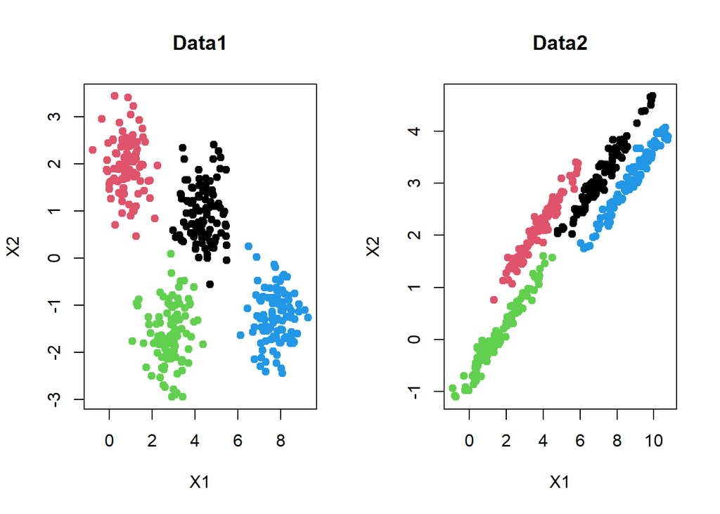

```r
data1 = read.csv("https://www.mghassany.com/MLcourse/datasets/data1.csv")
data2 = read.csv("https://www.mghassany.com/MLcourse/datasets/data2.csv")

par(mfrow=c(1,2))
plot(data1[1:2], main="Data1", pch=19, col=data1$truth)
plot(data2[1:2], main="Data2", pch=19, col=data1$truth)
```

### 2. Apply k-means on both datasets with 4 clusters. Plot both of the dataset on the same window and color the observations with respect to k-means results. Interpret the results.

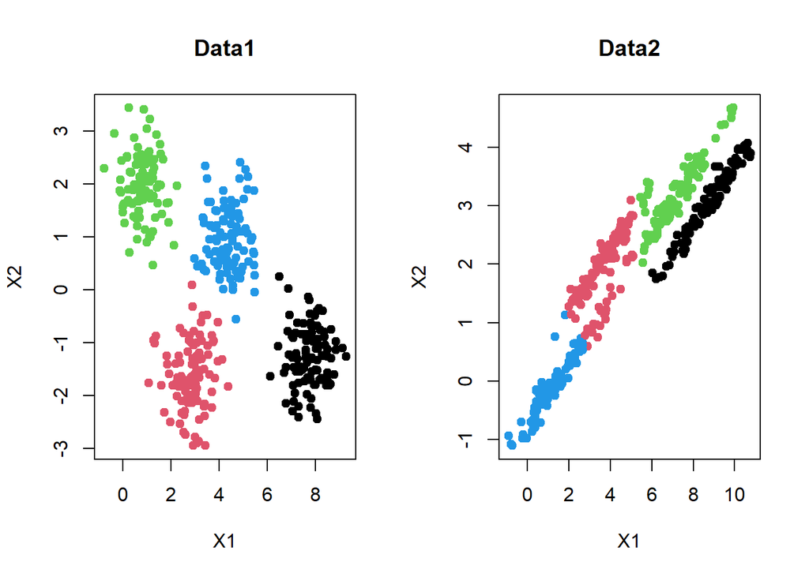

```r
set.seed(10)
km.data1 <- kmeans(data1,centers=4)
km.data2 <- kmeans(data2,centers=4)

par(mfrow=c(1,2))
plot(data1[1:2], main="Data1", pch=19, col=km.data1$cluster)
plot(data2[1:2], main="Data2", pch=19, col=km.data2$cluster)
```

Kmeans gives us good results with the first dataset whereas with the second one, the results are not really good. It’s because the algorithm try to minimize the distance between clusters so it is more approriate to use it when the clusters follow a circular pattern.

### 3. Now fit a GMM model on the datasets. To do so, load the mclust library. Then you can use the function Mclust() on your data (this function will choose automatically the number of mixtures, basing on BIC criterion). Use the clustering results from your GMM model to visualize the results on both of the datasets, color the observations with respect to the clusters obtained from the GMM model. Interpret the results.

```r
library(mclust)
```

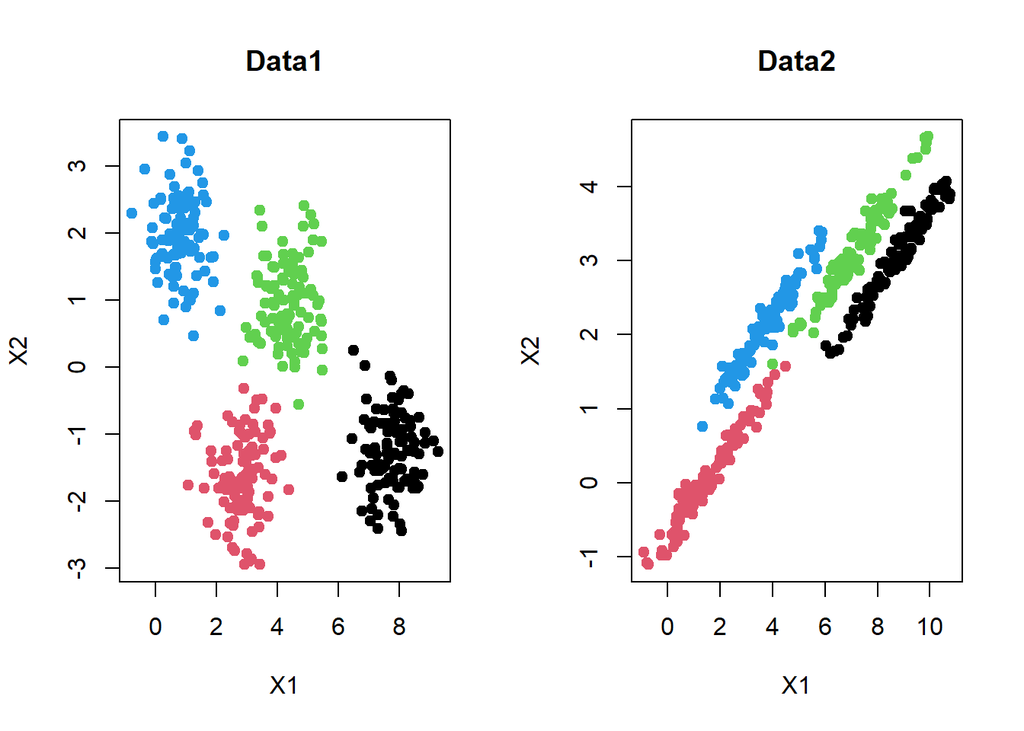

```r
gmm.data1 = Mclust(data1[1:2])
gmm.data2 = Mclust(data2[1:2])

par(mfrow=c(1,2))
plot(data1[1:2], main="Data1", pch=19, col=gmm.data1$classification)
plot(data2[1:2], main="Data2", pch=19, col=gmm.data2$classification)
```

The results are good for both datasets, because the GMM algorithm used density to find the clusters.

### 4. Show the summary of the GMM model you fitted on Data2. Explain what it shows.

```r
summary(gmm.data2)
```

```
## ----------------------------------------------------
## Gaussian finite mixture model fitted by EM algorithm
## ----------------------------------------------------
##
## Mclust EEE (ellipsoidal, equal volume, shape and orientation) model with 4
## components:
##
##  log-likelihood   n df       BIC       ICL
##       -938.8639 400 14 -1961.608 -1965.709
##
## Clustering table:
##   1   2   3   4
## 100  99 101 100
```

The summary gives us:  
- The number of samples per cluster - n: The number of observations in the data. - df: The number of estimated parameters - BIC: an indicator for choosing the number of components - ICl: an indicator for choosing the number of components - log-likelihood: The log-likelihood corresponding to the optimal BIC